# Craft Beer Case Study

# **4. Compute the median alcohol content and international bitterness unit for each state. Plot a bar chart to compare. ABV,IBU.**

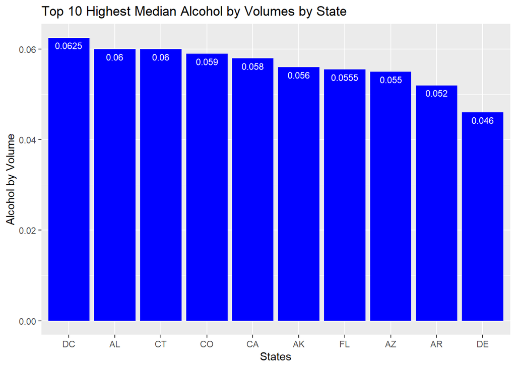

```r
nona$State = as.character(nona$State)
nona$State = str_trim(nona$State)

#Dataframe of just State,ABV,IBU
medianABVIBU<-nona%>%group_by(State)%>%summarize(medianABV=median(ABV),medianIBU=median(IBU))

#Code for Top 10 highes ABV by State
top10medABV=head(medianABVIBU,10)
top10medABV%>%ggplot(aes(x=reorder(State,-medianABV),y=medianABV))+
  geom_bar(stat="identity",fill="blue")+geom_text(aes(label=medianABV), vjust=1.6, color="white", size=3)+
ggtitle("Top 10 Highest Median Alcohol by Volumes by State")+xlab("States")+ylab("Alcohol by Volume")
```

```r
top10medABV[order(-top10medABV$medianABV),]
```

```
## # A tibble: 10 x 3
##    State medianABV medianIBU
##    <chr>     <dbl>     <dbl>
##  1 DC       0.0625      13
##  2 AL       0.06        39.5
##  3 CT       0.06        13
##  4 CO       0.059       40
##  5 CA       0.058       60
##  6 AK       0.056       40
##  7 FL       0.0555      36.5
##  8 AZ       0.055       20
##  9 AR       0.052       40
## 10 DE       0.046       76
```

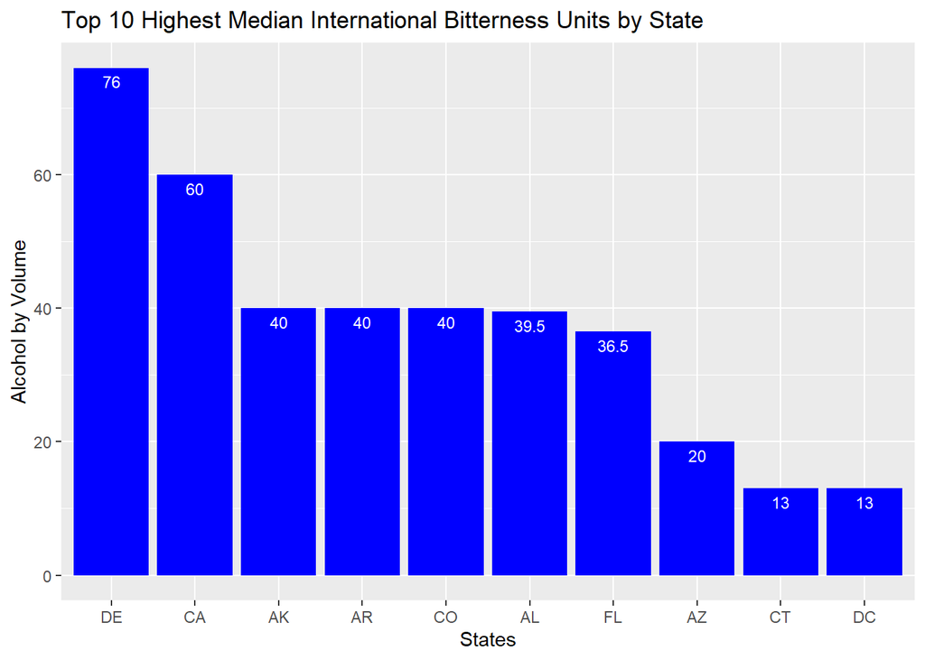

```r
top10medIBU=head(medianABVIBU,10)
top10medIBU%>%ggplot(aes(x=reorder(State,-medianIBU),y=medianIBU))+
  geom_bar(stat="identity",fill="blue")+geom_text(aes(label=medianIBU), vjust=1.6, color="white", size=3)+
ggtitle("Top 10 Highest Median International Bitterness Units by State")+xlab("States")+ylab("Alcohol by Volume")
```

```r
top10medIBU[order(-top10medIBU$medianIBU),]
```

```
## # A tibble: 10 x 3
##    State medianABV medianIBU
##    <chr>     <dbl>     <dbl>
##  1 DE       0.046       76
##  2 CA       0.058       60
##  3 AK       0.056       40
##  4 AR       0.052       40
##  5 CO       0.059       40
##  6 AL       0.06        39.5
##  7 FL       0.0555      36.5
##  8 AZ       0.055       20
##  9 CT       0.06        13
## 10 DC       0.0625      13
```

# **5. Which state has the maximum alcoholic (ABV) beer? Which state has the most bitter (IBU) beer?**

## *Colorado had the highest ABV and IBU values. The maxABV and maxIBU containe the top state value.*

```r
#Code to selct by ABV and IBU and find max value
maxABV<-nona%>%group_by(State)
maxIBU<-nona%>%group_by(State)
maxABV[which.max(maxABV$ABV), ]
```

```
## # A tibble: 1 x 10
## # Groups:   State [1]
##   Brewery_id Brewery_name City  State Beer_name Beer_ID   ABV   IBU Style
##        <int> <fct>        <fct> <chr> <fct>       <int> <dbl> <int> <fct>
## 1         52 Upslope Bre~ Boul~ CO    Lee Hill~    2565 0.128   108 Quad~
## # ... with 1 more variable: Ounces <dbl>
```

```r
maxIBU[which.max(maxIBU$IBU), ]
```

```
## # A tibble: 1 x 10
## # Groups:   State [1]
##   Brewery_id Brewery_name City  State Beer_name Beer_ID   ABV   IBU Style
##        <int> <fct>        <fct> <chr> <fct>       <int> <dbl> <int> <fct>
## 1          7 Great Divid~ Denv~ CO    Orabelle     2646 0.083   138 Trip~
## # ... with 1 more variable: Ounces <dbl>
```

# **6. Comment on the summary statistics and distribution of the ABV variable.**

## *The justABV variable holds only the ABV data. That is used to plot the raw data histogram for Alcohol by volume for the entire sample population. The standard hist() was used to create a simple plot with a normal curve.*

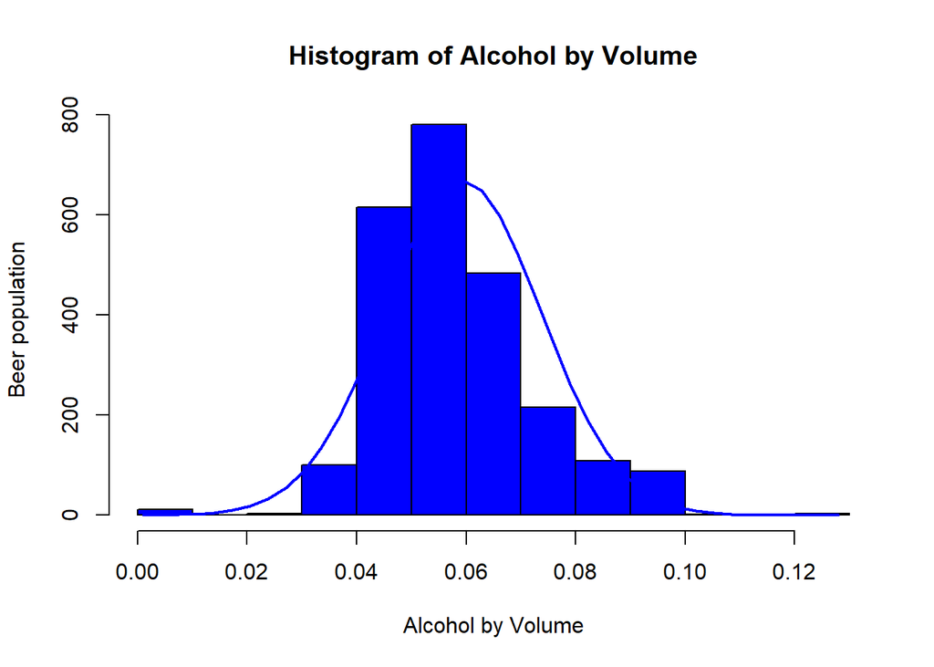

```r
x <- nona$ABV
h<-hist(x,
     main="Histogram of Alcohol by Volume",
     xlab="Alcohol by Volume",
     ylab="Beer population",
     col="blue",
     border="black"
     )
xfit<-seq(min(x),max(x),length=40)
yfit<-dnorm(xfit,mean=mean(x),sd=sd(x))
yfit <- yfit*diff(h$mids[1:2])*length(x)
lines(xfit, yfit, col="blue", lwd=2)
```

## *The summary(justABV) was used to create the summary statistics and a box plot using ggplot.*

```r
justABV<-nona%>%select(ABV)
summary(justABV*100)
```

```
##       ABV
##  Min.   : 0.100
##  1st Qu.: 5.000
##  Median : 5.600
##  Mean   : 5.933
##  3rd Qu.: 6.700
##  Max.   :12.800
```

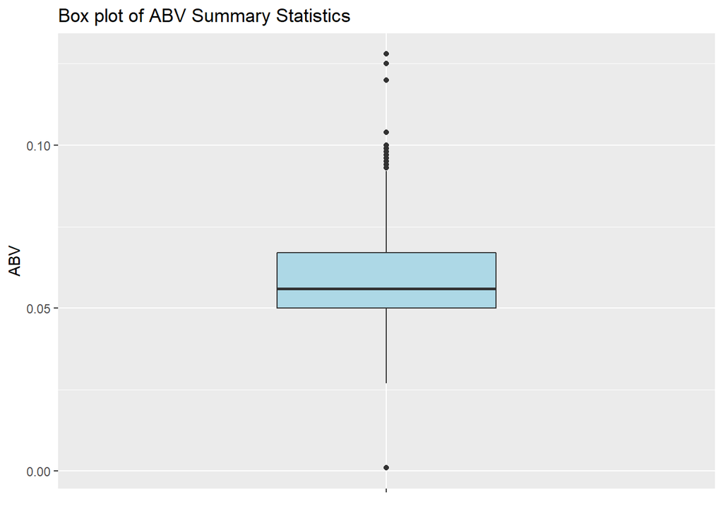

```r
justABV%>%ggplot(aes(x="", y=ABV,fill=ABV))+geom_boxplot(width=.4,fill="lightblue")+ylab("ABV")+ggtitle("Box plot of ABV Summary Statistics")+xlab(NULL)
```

## *justIBU was used to capture summary statistics for IBU including a boxplot.*

```r
justIBU<-nona%>%select(IBU)
summary(justIBU)
```

```
##       IBU
##  Min.   :  4.00
##  1st Qu.: 20.00
##  Median : 38.00
##  Mean   : 46.57
##  3rd Qu.: 66.00
##  Max.   :138.00
```

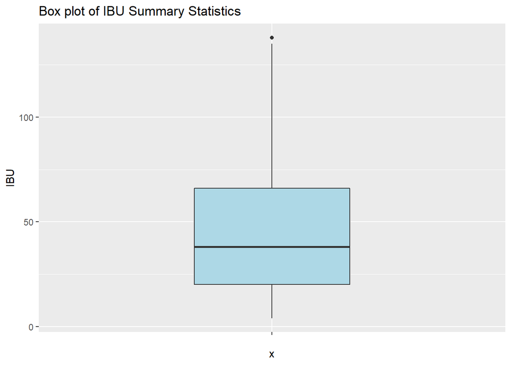

```r
justIBU%>%ggplot(aes(x="", y=IBU,fill=IBU))+geom_boxplot(width=.4,fill="lightblue")+ylab("IBU")+ggtitle("Box plot of IBU Summary Statistics")
```

# **7. Is there an apparent relationship between the bitterness of the beer and its alcoholic content? Draw a scatter plot. Make your best judgment of a relationship and EXPLAIN your answer.**

## *The scatter plots for this data was not conclusive and difficult to see patterns. This question is addressed further down.*

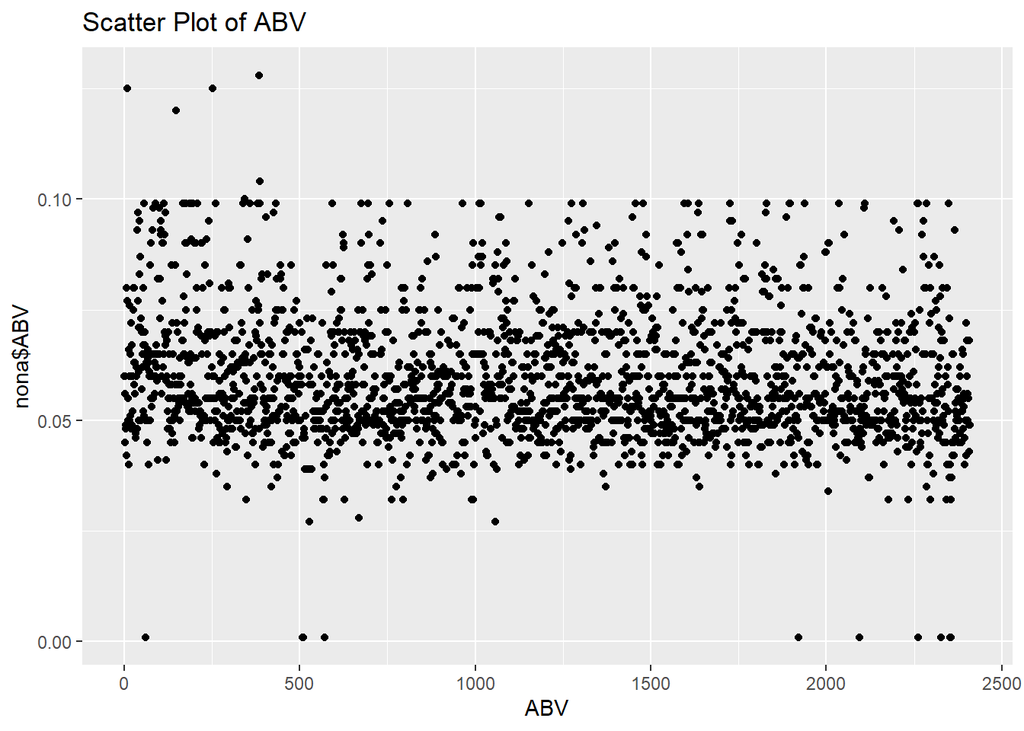

```r
qplot(seq_along(nona$ABV),nona$ABV,main="Scatter Plot of ABV",xlab="ABV")
```

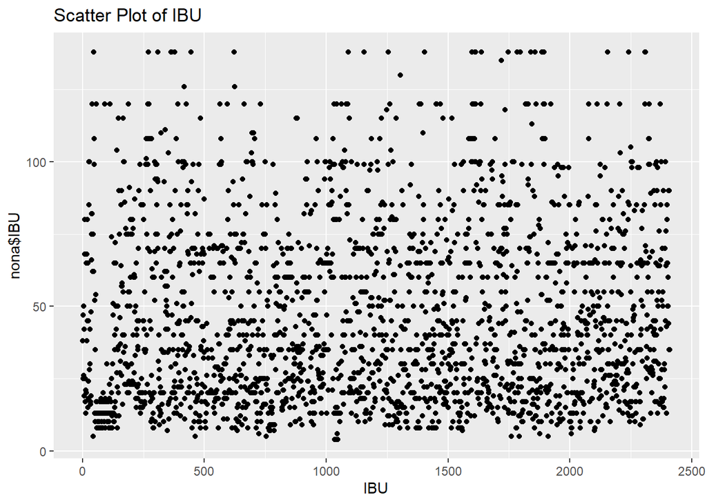

```r
qplot(seq_along(nona$IBU),nona$IBU, main="Scatter Plot of IBU",xlab="IBU")
```

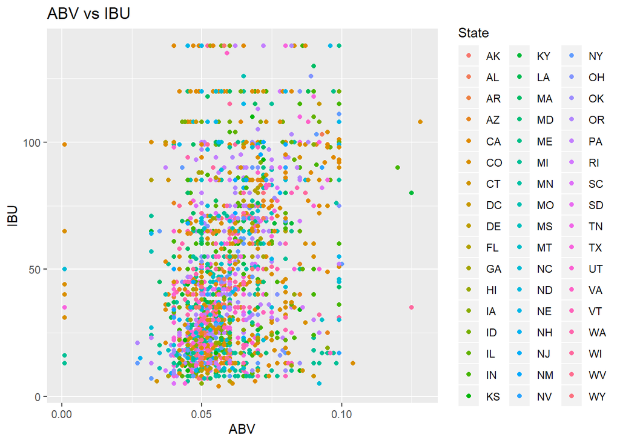

```r
styledf<-nona%>%select(State,Style,ABV,IBU)
styledf%>%ggplot(aes(x=ABV,y=IBU,color=State))+geom_point()+ggtitle("ABV vs IBU")
```

## *Jason’s code to support usmap libary. This code was modified to include a sum of breweries by state. That new column was later used to show a us map of number of breweries by state.*

```r
statesum = count(nona, vars = State)
brewerysum=breweriesdf%>%group_by(State)%>%summarise(Brewery_count=n())

temp = statepop
statesum$vars = as.character(statesum$vars)
statesum$vars = str_trim(statesum$vars)
brewerysum$State = as.character(brewerysum$State)
brewerysum$State = str_trim(brewerysum$State)
statebrew = merge(statesum, temp, by.x = "vars", by.y = "abbr")
names(statebrew)[names(statebrew) == "vars"] <- "abbr"
names(statebrew)[names(statebrew) == "n"] <- "count"
statebrew$per_cap <- statebrew$pop_2015 / statebrew$count
statebrew <- merge(brewerysum, statebrew, by.x = "State", by.y  = "abbr")
```

# **1.(continued) US map of breweries by state.**

## *This map shows the number of breweries accross all the states. The usmap library was used for these maps.*

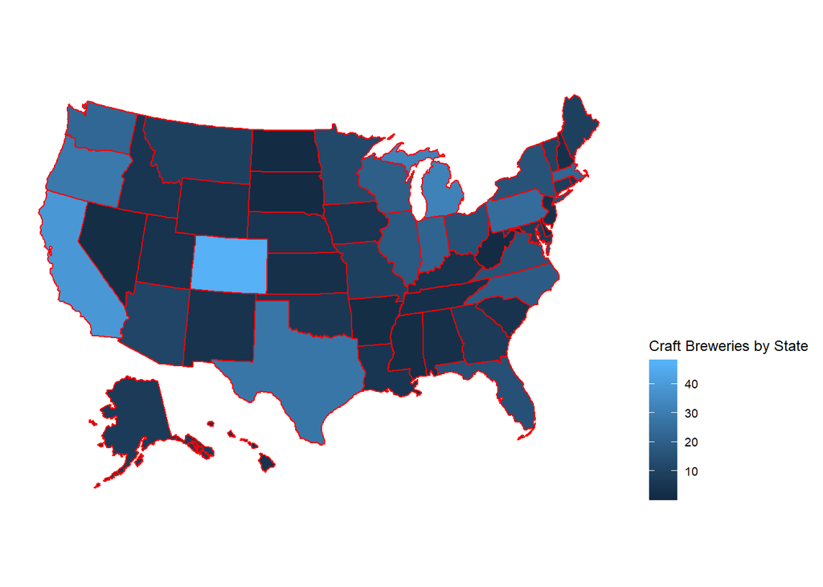

```r
plot_usmap(data = statebrew, values = "Brewery_count", color = "red") +
  scale_fill_continuous(name = "Craft Breweries by State", label = scales::comma) +
  theme(legend.position = "right")
```

## *US Maps plot of craft beers by state using the usmap library*

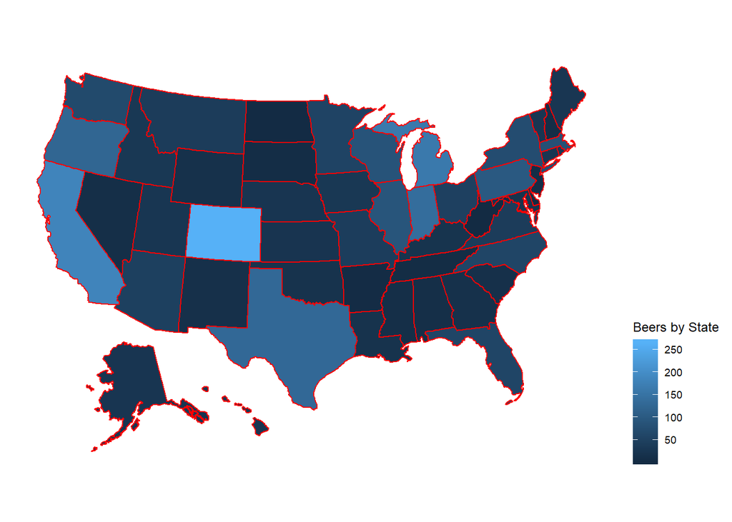

```r
plot_usmap(data = statebrew, values = "count", color = "red") +
  scale_fill_continuous(name = "Beers by State", label = scales::comma) + theme(legend.position = "right")
```

## *States population div by beers using the usmap library.*

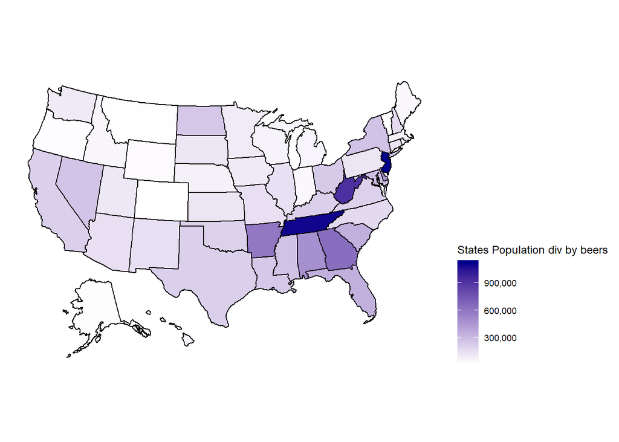

```r
plot_usmap(data = statebrew, values = "per_cap", color = "black") +
  scale_fill_continuous(
    low = "white", high = "darkblue", name = "States Population div by beers", label = scales::comma
  ) + theme(legend.position = "right")
```

## *Removed n/a’s and merged data to one master data frame*

```r
nona$State = as.character(nona$State)
nona$State = str_trim(nona$State)

allbrews = merge(statebrew, nona, by.x = "State", by.y = "State")
head(allbrews)
```

```
##   State Brewery_count count fips   full pop_2015  per_cap Brewery_id
## 1    AK             7    25   02 Alaska   738432 29537.28        224
## 2    AK             7    25   02 Alaska   738432 29537.28        103
## 3    AK             7    25   02 Alaska   738432 29537.28        103
## 4    AK             7    25   02 Alaska   738432 29537.28        103
## 5    AK             7    25   02 Alaska   738432 29537.28        103
## 6    AK             7    25   02 Alaska   738432 29537.28        103
##                   Brewery_name      City              Beer_name Beer_ID
## 1 Midnight Sun Brewing Company Anchorage          Pleasure Town    2093
## 2  King Street Brewing Company Anchorage              Amber Ale    2436
## 3  King Street Brewing Company Anchorage King Street Blonde Ale    1665
## 4  King Street Brewing Company Anchorage    King Street Pilsner    1706
## 5  King Street Brewing Company Anchorage        King Street IPA    1667
## 6  King Street Brewing Company Anchorage King Street Hefeweizen    1666
##     ABV IBU                    Style Ounces
## 1 0.063  61             American IPA     12
## 2 0.051  15 American Amber / Red Ale     12
## 3 0.049   7      American Blonde Ale     12
## 4 0.055  35           Czech Pilsener     12
## 5 0.060  70             American IPA     12
## 6 0.057  10               Hefeweizen     12
```

## *Compute the ABV,IBU state stats used for usmap plots.*

```r
stateABV = allbrews %>%
  group_by(State) %>%
  summarise_each(funs(max, min, mean, median, sd), ABV)
stateABV$max=stateABV$max*100
stateABV$min=stateABV$min*100
stateABV$median=stateABV$median*100

stateIBU = allbrews %>%
  group_by(State) %>%
  summarise_each(funs(max, min, mean, median, sd), IBU)

stateABV = merge(temp, stateABV, by.x = "abbr", by.y = "State")
stateIBU = merge(temp, stateIBU, by.x = "abbr", by.y = "State")
```

## *Map of ABV by state*

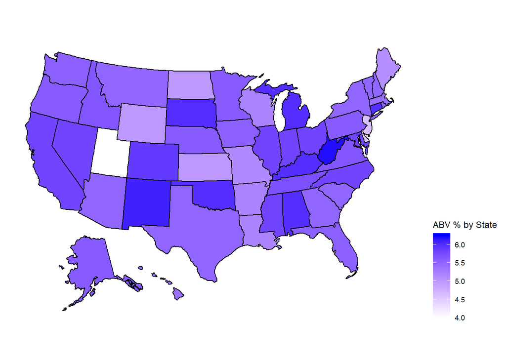

```r
plot_usmap(data = stateABV, values = "median", color = "black") + scale_fill_continuous(low = "white", high = "blue", name = "ABV % by State"  ) + theme(legend.position =
"right")
```

## *Map of IBU by state*

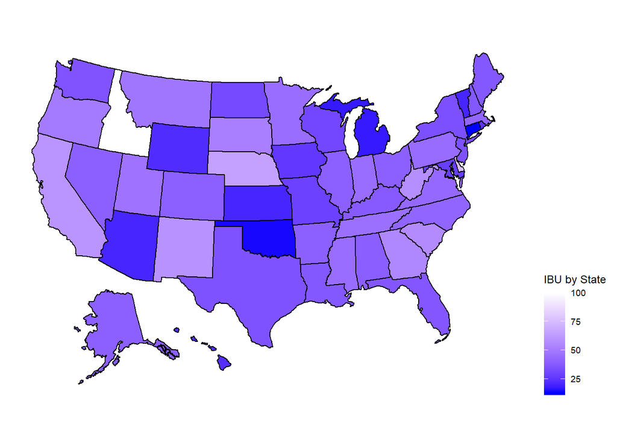

```r
plot_usmap(data = stateIBU, values = "median", color = "black") +
  scale_fill_continuous(
    low = "blue", high = "white", name = "IBU by State"  ) + theme(legend.position = "right")
```

# **5.cont for ABV**

## *Using usmaps to generate state of colorado with ABV %.*

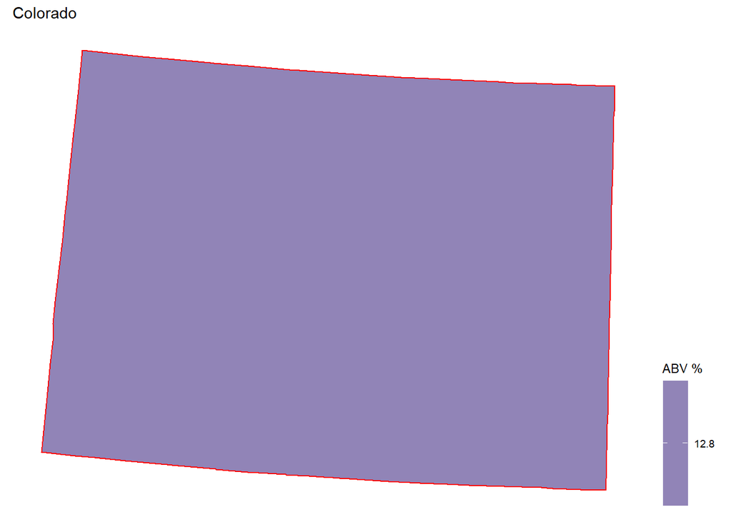

```r
plot_usmap(data = stateABV, values = "max", include = "CO", color = "red") + labs(title = "Colorado") +
  scale_fill_continuous(
    low = "white", high = "midnightblue", name = "ABV %"  ) + theme(legend.position = "right")
```

# **5.cont for IBU**

## *Using usmaps to generate state of colorado with IBU.*

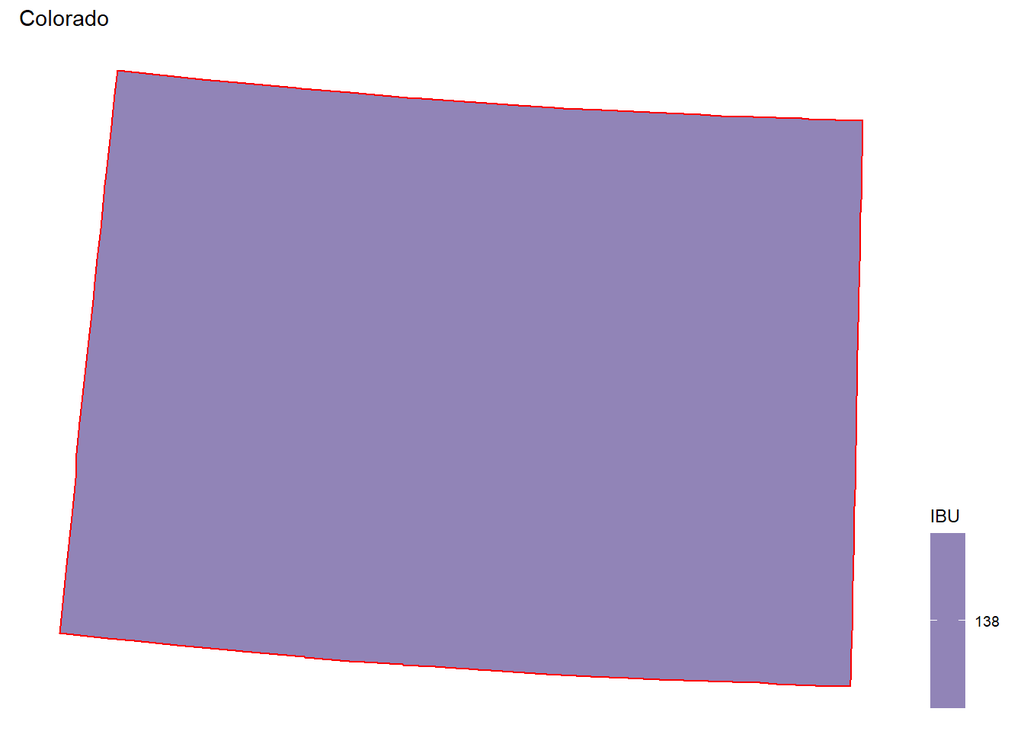

```r
plot_usmap(data = stateIBU, values = "max", include = "CO", color = "red") + labs(title = "Colorado") +
  scale_fill_continuous(
    low = "white", high = "midnightblue", name = "IBU"  ) + theme(legend.position = "right")
```

## **7. Linear regression analysis**

# *Linear regression of ABV and IBU with raw data to see if ther is a relationship.*

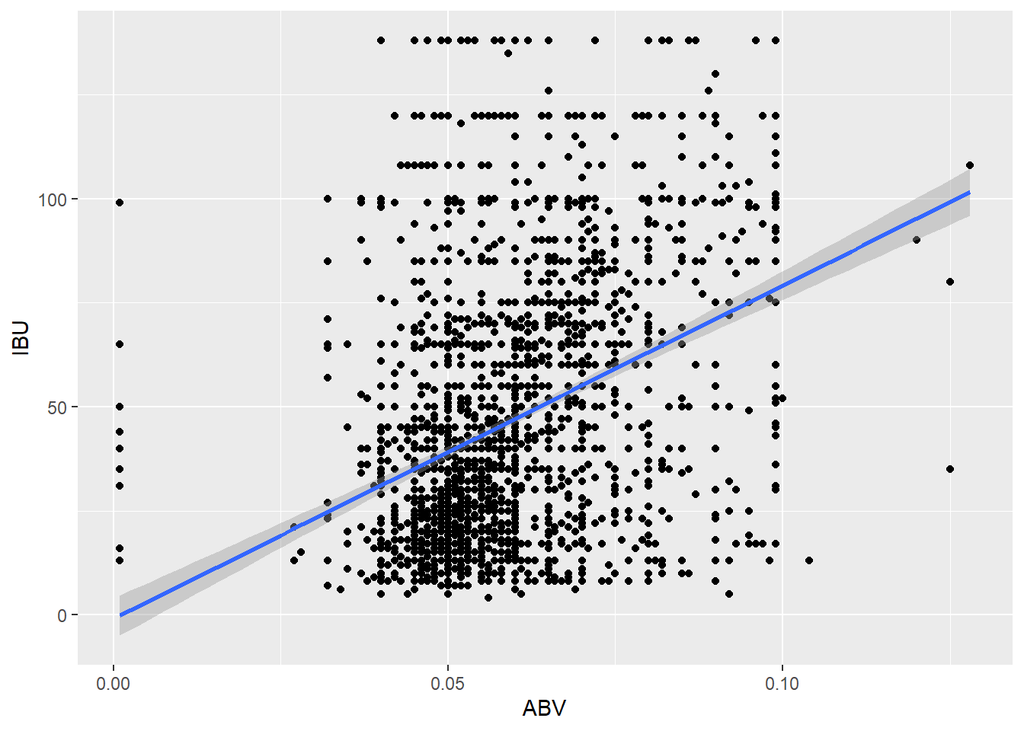

```r
nona%>%ggplot(aes(x=ABV,y=IBU))+geom_point()+geom_smooth(method="lm")
```

```r
fit = lm(IBU~ABV, data = nona)
summary(fit)
```

```
##
## Call:
## lm(formula = IBU ~ ABV, data = nona)
##
## Residuals:
##     Min      1Q  Median      3Q     Max
## -69.361 -20.887  -5.503  16.270 106.920
##
## Coefficients:
##             Estimate Std. Error t value Pr(>|t|)
## (Intercept)  -0.9706     2.4945  -0.389    0.697
## ABV         801.2621    40.8601  19.610   <2e-16 ***
## ---
## Signif. codes:  0 '***' 0.001 '**' 0.01 '*' 0.05 '.' 0.1 ' ' 1
##
## Residual standard error: 28.86 on 2408 degrees of freedom
## Multiple R-squared:  0.1377, Adjusted R-squared:  0.1373
## F-statistic: 384.5 on 1 and 2408 DF,  p-value: < 2.2e-16
```

# **Jason’s beer style code for Q7**

## *This code creates a class for beer Styles to make analysis easier and to enable the dot plot used to describe the relationship between style and ABV and IBU*

```r
styles = c("IPA", "APA", "Blonde ale", "brown ale", "red ale", "ale", "lager", "stout", "cider", "porter", "pilsner", "hefeweizen" ,"pilsener", "witbier", "fruit", "KÃ¶lsch")
beers = data.frame(styles)
beers$nodata = 0
allbrews$class = ""
allbrews$used = FALSE
allbrews$Beer_name = as.character(allbrews$Beer_name)
beers$styles = as.character(beers$styles)
for (i in 1:dim(allbrews)[1]) {
  for (j in 1:dim(beers)[1]) {
    x = beers[j,]$style
    y = allbrews[i,]$Style
    if (str_detect(y, regex(x, ignore_case = TRUE)) & allbrews[i,]$used != TRUE) {
      allbrews[i,]$class = beers[j,]$style
      allbrews[i,]$used = TRUE
    }
  }
}
for (i in 1:dim(allbrews)[1]) {
  if (allbrews[i,]$used == FALSE) {
    allbrews[i,]$class = "other"
  }
  if (allbrews[i,]$class == "Pilsener" | allbrews[i,]$class == "pilsener") {
    allbrews[i,]$class = "pilsner"
  }
}
```

## *The dot plot of the relationship between Styles of beer and their ABV and IBU along with a measure of popularity by looking at total populations of the beer style classifications. This plot shows the popularity of IPA’s along with their high ABV and IBU score. This plot gives us information about beer style popularity and it’s corresponding ABV and IBU.*

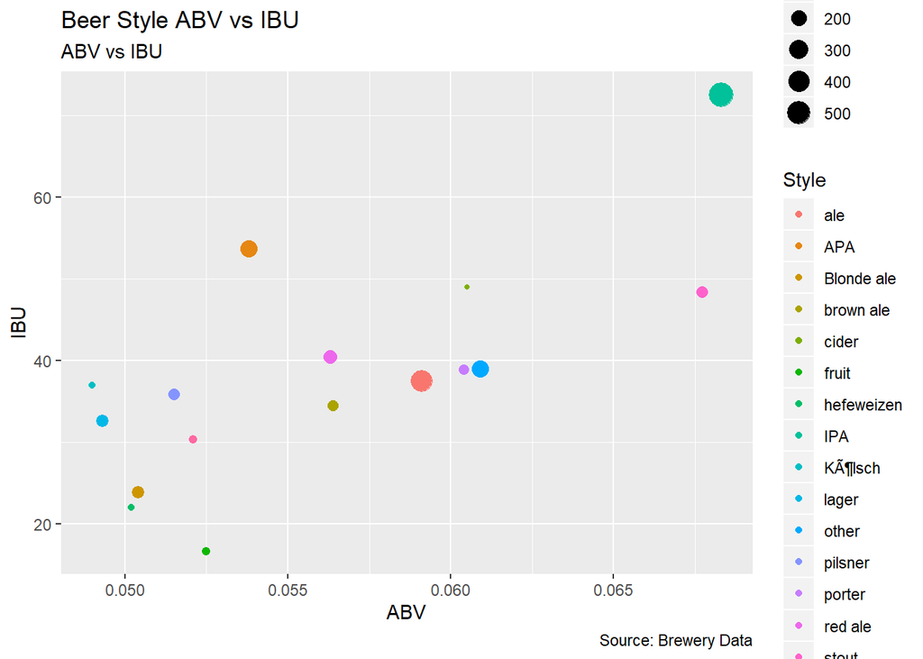

```r
stylesum = count(allbrews, vars = class)
stylemeans = stylesum
stylemeans$ABVmean = 0
stylemeans$IBUmean = 0
stylemeans$ABVtotal = 0
stylemeans$IBUtotal = 0
for (i in 1:dim(allbrews)[1]) {
  for (j in 1:dim(stylesum)[1]) {

    if (allbrews[i,]$class == stylesum[j,]$vars) {
      stylemeans[j,]$ABVtotal = stylemeans[j,]$ABVtotal + allbrews[i,]$ABV
      stylemeans[j,]$IBUtotal = stylemeans[j,]$IBUtotal + allbrews[i,]$IBU
    }

  }
}

for (j in 1:dim(stylemeans)[1]) {
  stylemeans[j,]$ABVmean = stylemeans[j,]$ABVtotal / stylemeans[j,]$n
  stylemeans[j,]$IBUmean = stylemeans[j,]$IBUtotal / stylemeans[j,]$n
}

stylemeans$ABVmean = round(stylemeans$ABVmean, 4)
stylemeans$IBUmean = round(stylemeans$IBUmean, 4)
names(stylemeans)[names(stylemeans) == "vars"] <- "abbr"
names(stylemeans)[names(stylemeans) == "n"] <- "count"


names(stylemeans)[names(stylemeans) == "abbr"] <- "Style"


gg <- ggplot(stylemeans, aes(x=ABVmean, y=IBUmean)) +
  geom_point(aes(col=Style, size=count)) +
  labs(subtitle="ABV vs IBU",
       y="IBU",
       x="ABV",
       title="Beer Style ABV vs IBU",
       caption = "Source: Brewery Data")

plot(gg)
```

# **8. Use KNN - For final presentation. Budweiser would also like to investigate the difference with respect #to IBU and ABV between IPAs (India Pale Ales) and other types of Ale (any beer with “Ale” in its name other than IPA). Classify IPA vs Regular Ale by ABV and IBU.**

```r
library(class)
library(caret)
library(e1071)

styleSubset <- nona%>%select(Style,ABV,IBU)
beermatch <- c("IPA","Ale")
allAles <-styleSubset[grep(paste(beermatch,collapse="|"),styleSubset$Style,ignore.case = TRUE),]

allAles$styleClass <- ifelse(grepl("IPA", allAles$Style,ignore.case = T), "IPA",
  ifelse(grepl("Ale", allAles$Style, ignore.case = T), "Ale", "Ale"))
allAles$styleClass <- as.vector(unlist(allAles$styleClass))

set.seed(6)
perc=.8
numks = 8

iterations=100
masterAcc = matrix(nrow = iterations, ncol = numks)
masterSensitivity = matrix(nrow = iterations)
masterSpecificity = matrix(nrow = iterations)

for(j in 1:iterations)
{
 accs = data.frame(accuracy=numeric(30),k=numeric(30))
 trainIndices = sample(1:dim(allAles)[1],
 round(perc * dim(allAles)[1]))
 train = allAles[trainIndices,]
 test = allAles[-trainIndices,]

  for(i in 1:numks)
  {
  classifications = knn(train[,c(2,3)],test[,c(2,3)],train$styleClass,   prob = TRUE, k = i)
  table(classifications,test$styleClass)
  CM = confusionMatrix(table(classifications,test$styleClass))
  masterAcc[j,i] = CM$overall[1]
  masterSensitivity[j]=CM$byClass[1]
  masterSpecificity[j]=CM$byClass[2]
  }
}
ptitle=print(paste0(numks," values of K for ",iterations," iterations."))
```

```
## [1] "8 values of K for 100 iterations."
```

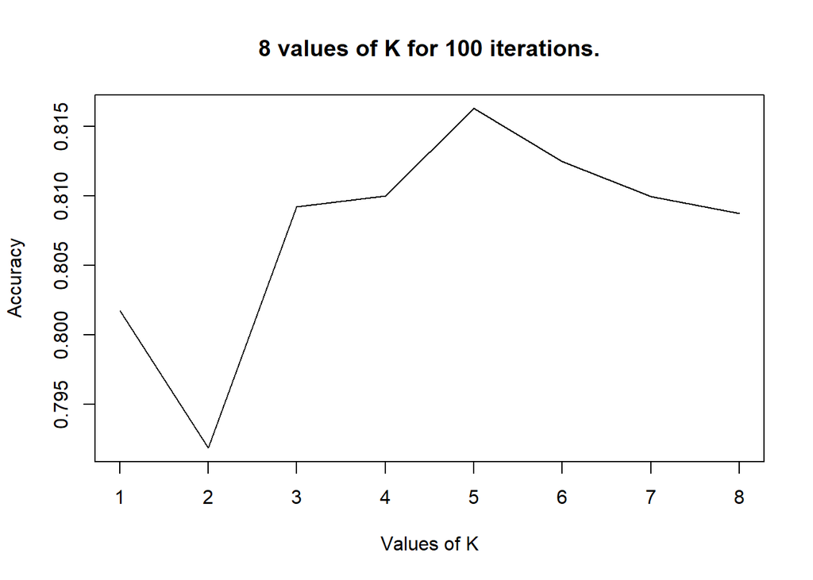

```r
MeanAcc = colMeans(masterAcc)
MeanSpec = mean(masterSpecificity)
MeanSens = mean(masterSensitivity)
plot(seq(1,numks,1),MeanAcc, type = "l",xlab = "Values of K",ylab = "Accuracy",main = ptitle)
```

```r
which.max(MeanAcc)
```

```
## [1] 5
```

```r
MeanSpec
```

```
## [1] 0.720715
```

```r
MeanSens
```

```
## [1] 0.8589438
```

```r
CM
```

```
## Confusion Matrix and Statistics
##
##
## classifications Ale IPA
##             Ale 181  36
##             IPA  24  75
##
##                Accuracy : 0.8101
##                  95% CI : (0.7625, 0.8519)
##     No Information Rate : 0.6487
##     P-Value [Acc > NIR] : 2.123e-10
##
##                   Kappa : 0.5728
##
##  Mcnemar's Test P-Value : 0.1556
##
##             Sensitivity : 0.8829
##             Specificity : 0.6757
##          Pos Pred Value : 0.8341
##          Neg Pred Value : 0.7576
##              Prevalence : 0.6487
##          Detection Rate : 0.5728
##    Detection Prevalence : 0.6867
##       Balanced Accuracy : 0.7793
##
##        'Positive' Class : Ale
##
```

## *Scatter plot of Ale vs IPA beer styles*

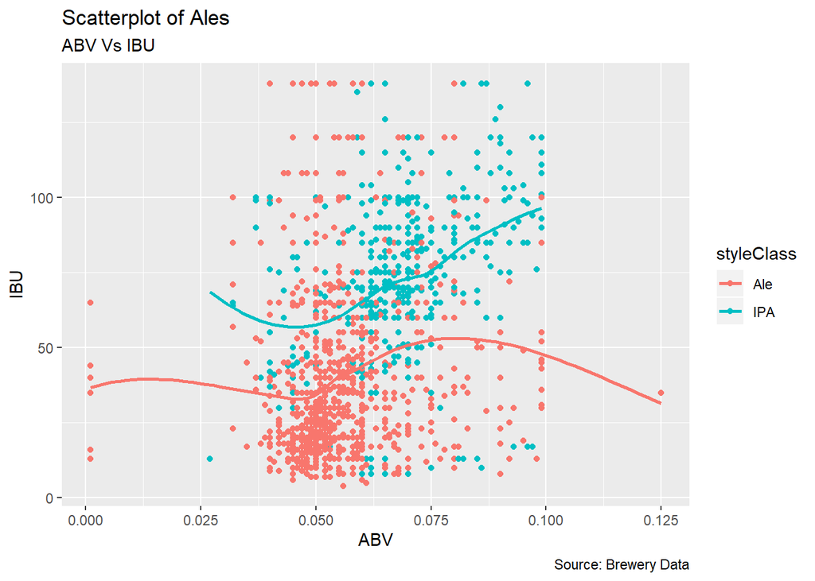

```r
Percent_ABV=allAles$ABV*100
gg <- ggplot(allAles, aes(x=ABV, y=IBU,col=styleClass)) +
 geom_point(aes()) +
 geom_smooth(method="loess", se=F) +
 labs(subtitle="ABV Vs IBU",
      y="IBU",
      x="ABV",
      title="Scatterplot of Ales",
      caption = "Source: Brewery Data")
plot(gg)
```